# Concatenating, Joining, and Pivoting Data

There are several ways of answering many questions in this notebook, but try to use the new operations (concatenate, joint/merge, pivot) whenever possible to get practice.

```python
import pandas as pd
```

## Movie Ratings Data

The Movielens data set (https://dlsun.github.io/pods/data/ml-1m/ ) contains 1 million movie ratings submitted by users. The information about the movies, ratings, and users are stored in three separate files, called `movies.dat`, `ratings.dat`, and `users.dat`. The column names are not included with the data files. Refer to the webpage above for more information.

1. Read in each of the data files.

(Hint: see the note in the documentation about the delimiter; use the `sep` argument in `read_csv`. If you get an error when reading the `movies.dat` file, try `encoding_errors = "ignore"` in `read_csv`.)

```python
# YOUR CODE HERE
base = "https://dlsun.github.io/pods/data/ml-1m/"

movies_url = base + "movies.dat"
ratings_url = base + "ratings.dat"
users_url = base + "users.dat"

movies_df = pd.read_csv(movies_url, sep="::",
                        encoding_errors="ignore",
                        header = None, names = ["movie_id", "title", "genre"]
                        )

ratings_df = pd.read_csv(ratings_url, sep="::",
                        encoding_errors="ignore",
                        header = None, names = ["user_id", "movie_id", "rating", "timestamp"]
                        )

users_df = pd.read_csv(users_url, sep="::",
                        encoding_errors="ignore",
                        header = None, names = ["user_id", "gender", "age", "occupation", "zip"]
                        )
```

```python
movies_df.head()
```

|  | movie_id | title | genre |
| --- | --- | --- | --- |
| 0 | 1 | Toy Story (1995) | Animation\|Children's\|Comedy |
| 1 | 2 | Jumanji (1995) | Adventure\|Children's\|Fantasy |
| 2 | 3 | Grumpier Old Men (1995) | Comedy\|Romance |
| 3 | 4 | Waiting to Exhale (1995) | Comedy\|Drama |
| 4 | 5 | Father of the Bride Part II (1995) | Comedy |

2. Which age group tends to give the highest ratings? Create an appropriate summary to answer this question.

(Note the way age is coded in the [REAMDE file](https://dlsun.github.io/pods/data/ml-1m/README.txt).)

```python
# YOUR CODE HERE
rating_users_df = ratings_df.merge(users_df, on ="user_id", how = "left", validate="many_to_one")

age_label = {1:"<18", 18:"18-24", 25:"25-34",35:"35-44", 45:"45-49",50:"50-55", 56:"56+"}
rating_users_df["age_group"]= rating_users_df["age"].map(age_label)

rating_users_df. groupby("age_group")["rating"].agg(n_rating = "size", mean_rating = "mean").sort_values("mean_rating", ascending=False). reset_index()
```

|  | age_group | n_rating | mean_rating |
| --- | --- | --- | --- |
| 0 | 56+ | 38780 | 3.766632 |
| 1 | 50-55 | 72490 | 3.714512 |
| 2 | 45-49 | 83633 | 3.638062 |
| 3 | 35-44 | 199003 | 3.618162 |
| 4 | <18 | 27211 | 3.549520 |
| 5 | 25-34 | 395556 | 3.545235 |
| 6 | 18-24 | 183536 | 3.507573 |

3. Among movies with at least 100 ratings, which movies had the highest average rating? The lowest?

```python
# YOUR CODE HERE

sum_ratings_df = ratings_df.groupby("movie_id")["rating"].agg(n_ratings="size", mean_rating="mean").reset_index()

movies_ratings_df = sum_ratings_df.merge(movies_df,on="movie_id",how="left",validate="many_to_one")

more_than_100_ratings = movies_ratings_df[movies_ratings_df["n_ratings"] >= 100]

more_than_100_ratings.sort_values("mean_rating",ascending=False).head()
```

|  | movie_id | n_ratings | mean_rating | title | genre |
| --- | --- | --- | --- | --- | --- |
| 1839 | 2019 | 628 | 4.560510 | Seven Samurai (The Magnificent Seven) (Shichin... | Action\|Drama |
| 309 | 318 | 2227 | 4.554558 | Shawshank Redemption, The (1994) | Drama |
| 802 | 858 | 2223 | 4.524966 | Godfather, The (1972) | Action\|Crime\|Drama |
| 708 | 745 | 657 | 4.520548 | Close Shave, A (1995) | Animation\|Comedy\|Thriller |
| 49 | 50 | 1783 | 4.517106 | Usual Suspects, The (1995) | Crime\|Thriller |

4. For each movie, calculate the average rating and the proportion of the ratings that were from users aged 18-24. Make a scatterplot showing the relationship between the average rating and the 18-24 share, with each point representing a movie. (Optional: Use the size of each point to represent the number of users who rated the movie.)

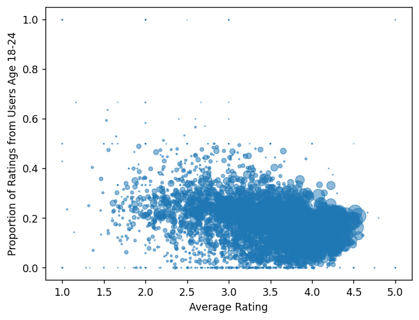

```python
# YOUR CODE HERE

movie_age_summary = (rating_users_df.groupby("movie_id")
.agg(
    mean_rating=("rating", "mean"),
    n_ratings=("rating", "size"),
    share_18_24=("age", lambda x: (x == 18).mean())
    ).reset_index()
)

import matplotlib.pyplot as plt

plt.scatter(
    movie_age_summary["mean_rating"],
    movie_age_summary["share_18_24"],
    s=movie_age_summary["n_ratings"] / 10,
    alpha=0.5
    )

plt.xlabel("Average Rating")
plt.ylabel("Proportion of Ratings from Users Age 18-24")
plt.show()
```

5. Calculate the number of ratings by movie. How many of the movies had zero ratings?

(*Hint*: Why is an inner join not sufficient here?)

```python
# YOUR CODE HERE

n_ratings_df = ratings_df.groupby("movie_id")["rating"].agg(n_ratings="size").reset_index()

movies_n_ratings_df = movies_df.merge(n_ratings_df, on="movie_id", how="left")

movies_n_ratings_df["n_ratings"] = movies_n_ratings_df["n_ratings"].fillna(0)

movies_n_ratings_df[movies_n_ratings_df["n_ratings"] == 0].shape[0]
```

```
177
```

6. How many movies received both a 1 and a 5 rating? Which movies? How many ratings of each type (1 or 5 stars)? Answer these question by joining two appropriate tables.

```python
# YOUR CODE HERE

one_star_df = ratings_df[ratings_df["rating"] == 1].groupby("movie_id")["rating"].agg(n_1_star="size").reset_index()

five_star_df = ratings_df[ratings_df["rating"] == 5].groupby("movie_id")["rating"].agg(n_5_star="size").reset_index()

one_five_df = one_star_df.merge(five_star_df, on="movie_id", how="inner")

one_five_movies_df = one_five_df.merge(movies_df, on="movie_id", how="left")

one_five_movies_df
```

|  | movie_id | n_1_star | n_5_star | title | genre |
| --- | --- | --- | --- | --- | --- |
| 0 | 1 | 16 | 820 | Toy Story (1995) | Animation\|Children's\|Comedy |
| 1 | 2 | 42 | 48 | Jumanji (1995) | Adventure\|Children's\|Fantasy |
| 2 | 3 | 44 | 43 | Grumpier Old Men (1995) | Comedy\|Romance |
| 3 | 4 | 21 | 6 | Waiting to Exhale (1995) | Comedy\|Drama |
| 4 | 5 | 28 | 16 | Father of the Bride Part II (1995) | Comedy |
| ... | ... | ... | ... | ... | ... |
| 2981 | 3948 | 35 | 163 | Meet the Parents (2000) | Comedy |
| 2982 | 3949 | 9 | 132 | Requiem for a Dream (2000) | Drama |
| 2983 | 3950 | 2 | 12 | Tigerland (2000) | Drama |
| 2984 | 3951 | 1 | 14 | Two Family House (2000) | Drama |
| 2985 | 3952 | 9 | 83 | Contender, The (2000) | Drama\|Thriller |

2986 rows × 5 columns